# R Notebook

# 1. Documentation

## 1.1 Domain Knowledge

CitiBikes is a bikesharing system operating in New York City, and is the largest bike sharing program in America despite only serving in one city. CitiBike provides customers an affordable and environmentally friendly mode of transport by hosting banks of bicycles at various different “stations” across the city, that customers can “dock” in and out of with ease. The scheme allows for a customer to hire their bicycle at any station in the city, and park their bike at any other station, allowing customers to get from A to B without having to worry about returning their bike. The hiring process is completed entirely through an app, negating the need for opening times or manned stations. CitiBikes possesses 25000 bikes and offers a range of bicycle styles including classic and electric bicycles, and has over 1500 stations across New York City.

## 1.3 Business Processes and Data Flow

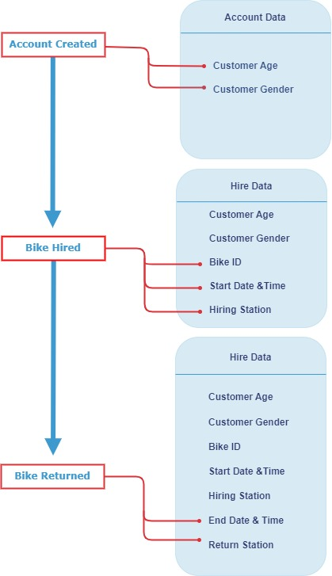

Data Collection Flow

Data is collected at the beginning and end of the hiring process. In order to hire a bike, the customer must first create an account with CitiBike, this collects the customer’s gender and age, amognst other personal details that have been left out of this dataset to allow anonymity. Once the customer then chooses to hire a bike, the hire time, hire station, and bike ID are recorded. Once the customer returns the bike at one of the docks, the stop time and stop station are recorded.

## 1.4 Data visualisation as a tool for decision-making

This report will provide insight into hiring patterns over time as well as hiring patterns across customer demographics. These insights will allow CitiBikes to identify trends and relationships which will aid them to make informed decisions.

## 1.5 Data Types

# 2. Data Cleaning

# 3. Data Visualisations

First, I investigated how hiring patterns differ over time. This data set provides a sample of the data over a span of the year. Therefore, I deemed it most notable to understand the trend of data on a weekly to daily basis. To provide further insight, it would be useful to sample data from other years to be able to gather better insight to the month to year trends.

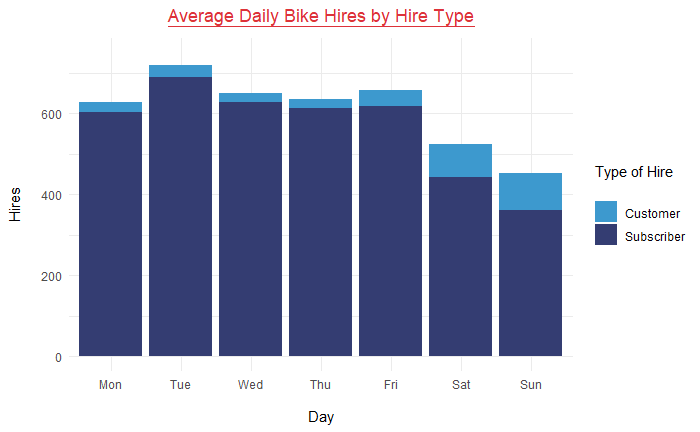

```r
nyc_bikes_df %>%
  index_by(start_wkday) %>%
  group_by(type) %>%
  summarise(mean = mean(n())) %>%
  ggplot(aes(x = factor(start_wkday,
                        level = c("Mon", "Tue", "Wed", "Thu", "Fri", "Sat", "Sun")),
             y = mean,
             fill = type)) +
  geom_col() +
  xlab("\nDay") +
  ylab("Hires\n") +
  labs(fill = "Type of Hire\n") +
  ggtitle(expression(underline("Average Daily Bike Hires by Hire Type"))) +
  theme_minimal() +
  scale_fill_manual(values = c("Subscriber" = "#343d72",
                               "Customer" = "#3d99ce")) +
  theme(plot.title = element_text(family = "sans", face = "bold", hjust = 0.5, colour = "#dd3239" ))+

  ylim(0,750)
```

This plot displays the average number of bikes hired on each day of the week. Each bar is split by the “hire type”, i.e does the customer pay a monthly subscription or do they pay as they go. It is evident from this plot that the most popular day for CitiBikes is Tuesday. There is a reduction of hires over the weekend, however the ratio of customer to subscriber moves to favour one-off (“customer”) hires at the weekend.

To provide further insight into this differing customer behaviour at the weekend versus during the week, I investigated the pattern of hires on an hourly basis, and compared weekday patterns to weekend patterns:

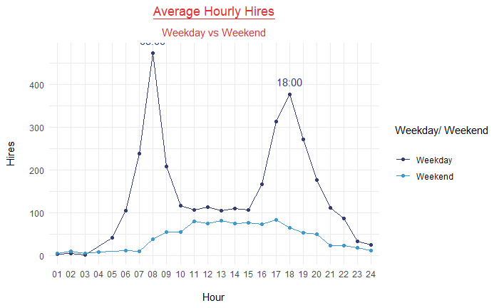

```r
nyc_bikes_df_day <- nyc_bikes_df %>%
  mutate(day_type = ifelse(start_wkday %in% c("Sat", "Sun"), "Weekend", "Weekday")) %>%
  group_by(day_type) %>%
  index_by(start_hour) %>%
  summarise(count = n())

nyc_bikes_df_day <- as.tibble(nyc_bikes_df_day) %>%
  mutate(start_hour = str_pad(start_hour, 2, pad = "0")) %>%
  mutate(start_hour = str_replace(as.character(start_hour), "00", "24")) %>%
  mutate(label_text = ifelse(count %in% c(474, 377), paste0(start_hour,":00"), NA))

  nyc_bikes_df_day %>%
  ggplot(aes(x = start_hour, y = count, group = day_type, colour = day_type)) +
  geom_point() +
  geom_text(aes(label = label_text), vjust = -1, show.legend = FALSE) +
    geom_line() +
  xlab("\nHour") +
  ylab("Hires\n") +
  labs(colour = "Weekday/ Weekend\n") +
  ggtitle(expression(underline("Average Hourly Hires")),
          subtitle = "Weekday vs Weekend" ) +
     theme_minimal() +
  scale_colour_manual(values = c("Weekday" = "#343d72",
                               "Weekend" = "#3d99ce")) +
  theme(plot.title = element_text(family = "sans", face = "bold", hjust = 0.5, colour = "#dd3239"))+
    theme(plot.subtitle = element_text(family = "sans", face = "plain", hjust = 0.5, colour = "#dd3239"))
```

```r
  ylim(0,750)
```

```
<ScaleContinuousPosition>
 Range:
 Limits:    0 --  750
```

From this plot, weekday hires are mostly taken during peak commuting times at the start and end of the business day. Weekend hires are much more linear throughout the middle of the day.